# iterative_beta

```python
from IPython.display import HTML

HTML('''<script>
code_show=true;
function code_toggle() {
 if (code_show){
 $('div.input').hide();
 } else {
 $('div.input').show();
 }
 code_show = !code_show
}
$( document ).ready(code_toggle);
</script>
<form action="javascript:code_toggle()"><input type="submit" value="Click here to toggle on/off the raw code."></form>''')
```

*Iterative solution for $\beta(r)$*

Idea: Iteratively calculate $\beta(r)$. Start by calculating the density perturbation due to the tidal potential. Then adjust the potential, accounting for this density perturbation. Then, use this new potential to recalculate the density perturbation. Iterate until convergence is achieved.

Notation: For convenience we set G = 1. We only consider the quadrupole ($l=2$) component of the potential. We only write out the $m=2$ components of the potential. The other non-zero components (m=-2, m=0) can be considered independently, and they would not change the calculation below.

The tidal potential is

$U(r, \theta, \phi)=U_o r^2 Y_{22}(\theta, \phi)$.

The Eulerian density perturbation within the star is

$\rho'(r, \theta, \phi)= \frac{\beta(r) U \partial_r \rho_o}{\partial_r \Phi_o}\equiv \chi(r) r^2 U_o Y_{22}(\theta, \phi)$,

Where $\chi(r)=\frac{\beta(r) \partial_r \rho_o}{\partial_r \Phi_o}$. Initially we set $\beta(r)=1$. This density perturbation will change the potential within the star by

$\delta U(r,\theta, \phi)=-\int \frac{\rho'(\mathbf{r'})}{|\mathbf{r}-\mathbf{r'}|} r'^2 dr' \sin(\theta') d\theta' d\phi'$

$\approx -\frac{4 \pi U_o}{2 l+1} Y_{22} (\theta, \phi) \left[\frac{1}{r^3} \int_{0}^r \chi(r') r'^6 dr'+r^2 \int_{r}^1 r' \chi(r') d r'\right] $.

In the first line the integral is over the volume of the star. In the second line we have expanded the denominator using eq. 3.70 in Jackson. The total potential perturbation is $\Phi' =\beta(r) U = U +\delta U$. Thus,

$\beta(r) = 1-\frac{4 \pi}{2 l+1} \left[\frac{1}{r^5} \int_{0}^r \chi(r') r'^6 dr'+\int_{r}^1 r' \chi(r') d r'\right].$

Next we iteratitively calculate $\beta$ and $\chi$.

**Results**

The iterative method gives $\beta(1)$ in good agreement with the mode summation method for a range of polytropic indices. e.g.

|  | n | $\beta(1)$ (modes) | $\beta(1)$ (iterative) |  |
| --- | --- | --- | --- | --- |
|  | 1 | 1.57 | 1.52 |  |
|  | 1.5 | 1.29 | 1.29 |  |
|  | 2 | 1.15 | 1.15 |  |
|  | 3 | 1.03 | 1.03 |  |

Convergence is achieved within $\sim 5$ iterations.

We can also solve for $\beta(r)$ using Poisson's equation. The plot below compares $\beta(r)$ from Poisson's equation with our iterative and mode summation solutions. For the former we set $\beta'(0)=0$ and $\beta(0)=3.6$ to match the iterative solution at the origin.

Unfortunately $\beta(r)$ from mode summation matches the two other solutions only at the surface.

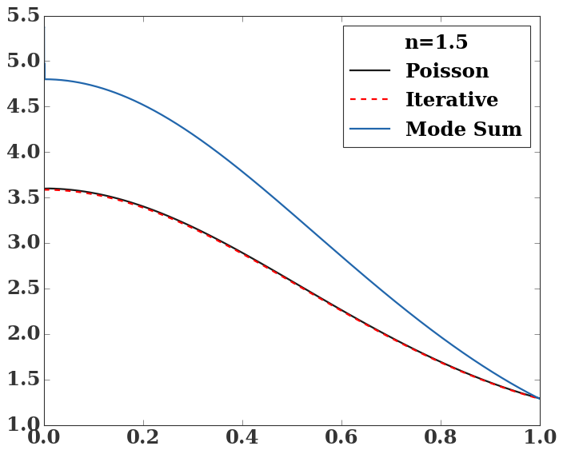

```python
%pylab inline

beta_poisson=np.genfromtxt('beta_poisson_1.5.tsv')
plot(beta_poisson[:,0], beta_poisson[:,1], label='Poisson')

beta_iter=np.genfromtxt('beta_iter_1.5.tsv')
plot(beta_iter[:,0], beta_iter[:,1], 'r--', label='Iterative')

beta_mode_sum=np.genfromtxt('beta_mode_sum_1.5.tsv')
plot(beta_mode_sum[:,0], beta_mode_sum[:,1], label='Mode Sum')

# annotate('n=1.5', (0.4, 5))
legend(title='n=1.5')
```